# College Tuition

Evelyn Sun, Benji Sun, Selena Li, Steven Huang

## Introduction

Our source: [data source](https://www.kaggle.com/jessemostipak/college-tuition-diversity-and-pay)

Our domain of interests primarily focus on datasets related to college life. We found three datasets before which included college-tuition dataset, college-basketball dataset and college-majors dataset.

Basically we’re interested in this aspect because they are somehow connnected to our school life. By researching and analyzing those data, it is a great opportunity for us to have a more well-rounded understanding with regard to this.

Finally, by considering the details of three datasets, we choose the college-tuition dataset as our main reasearch emphases. This dataset is both easily understandable and has sufficient data, which makes this dataset more reliable.

## Summary Information

Here is the summary information we got from our data:

```
## $length
## [1] 10
##
## $num_public
## [1] 1584
##
## $num_private
## [1] 1281
##
## $num_for_profit
## [1] 107
##
## $avg_instate_tuition
## [1] 16491.29
##
## $avg_out_of_state_tuition
## [1] 20532.73
##
## $avg_instate_public
## [1] 6037.799
##
## $avg_instate_private
## [1] 29432.44
##
## $avg_outstate_public
## [1] 13615.96
##
## $avg_outstate_private
## [1] 29436.48
##
## $most_expensive_instate
## [1] "Columbia University"
##
## $most_expensive_outstate
## [1] "Columbia University"
```

## Table

The purpose of this table is to compare the total cost of students by finding the difference between in-state total cost and out-of-state total cost.

| Name | State | Type | In-state Cost | Out-state Cost | Difference |
| --- | --- | --- | --- | --- | --- |
| University of Michigan | Michigan | Public | 26796 | 60884 | 34088 |
| University of Virginia | Virginia | Public | 29154 | 60055 | 30901 |
| University of California: Davis | California | Public | 30674 | 59669 | 28995 |
| University of California: Berkeley | California | Public | 30344 | 59336 | 28992 |
| University of California: Irvine | California | Public | 30877 | 59869 | 28992 |
| University of California: Los Angeles | California | Public | 29590 | 58582 | 28992 |
| University of California: Riverside | California | Public | 33108 | 62100 | 28992 |
| University of California: San Diego | California | Public | 26561 | 55553 | 28992 |
| University of California: Santa Barbara | California | Public | 29697 | 58689 | 28992 |
| University of Maryland: Baltimore | Maryland | Public | 11033 | 39267 | 28234 |
| University of California: Merced | California | Public | 30081 | 58095 | 28014 |
| University of California: Santa Cruz | California | Public | 30416 | 58430 | 28014 |
| University of Texas at Austin | Texas | Public | 21410 | 48284 | 26874 |
| Virginia Military Institute | Virginia | Public | 28290 | 55134 | 26844 |
| University of Wisconsin-Madison | Wisconsin | Public | 21669 | 47919 | 26250 |
| University of North Carolina at Chapel Hill | North Carolina | Public | 20177 | 46360 | 26183 |
| Texas A&M University | Texas | Public | 21404 | 46878 | 25474 |
| University of Washington | Washington | Public | 24315 | 49696 | 25381 |
| University of Washington Bothell | Washington | Public | 23015 | 48396 | 25381 |
| University of Washington Tacoma | Washington | Public | 22389 | 47770 | 25381 |

## Chart

### Chart 1

This chart shows the relationship between in-state tuition and out-state tuition with regard to colleges that are private, public, or run for profits.

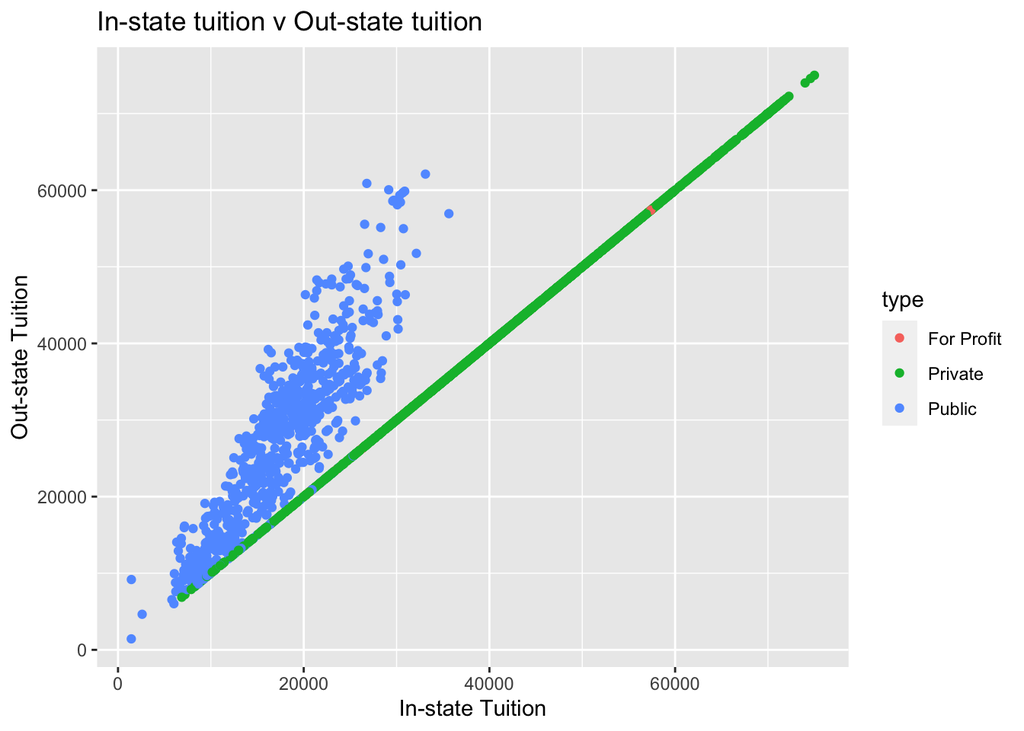

We choose this chart to express this relationship because color points make it clear showing what out-state and in-state are like in different school types. Besides that, the axis data are also helpful showing the tuition.

### Chart 2

This chart shows the relationship between in-state tuition and room & boards in different colleges.

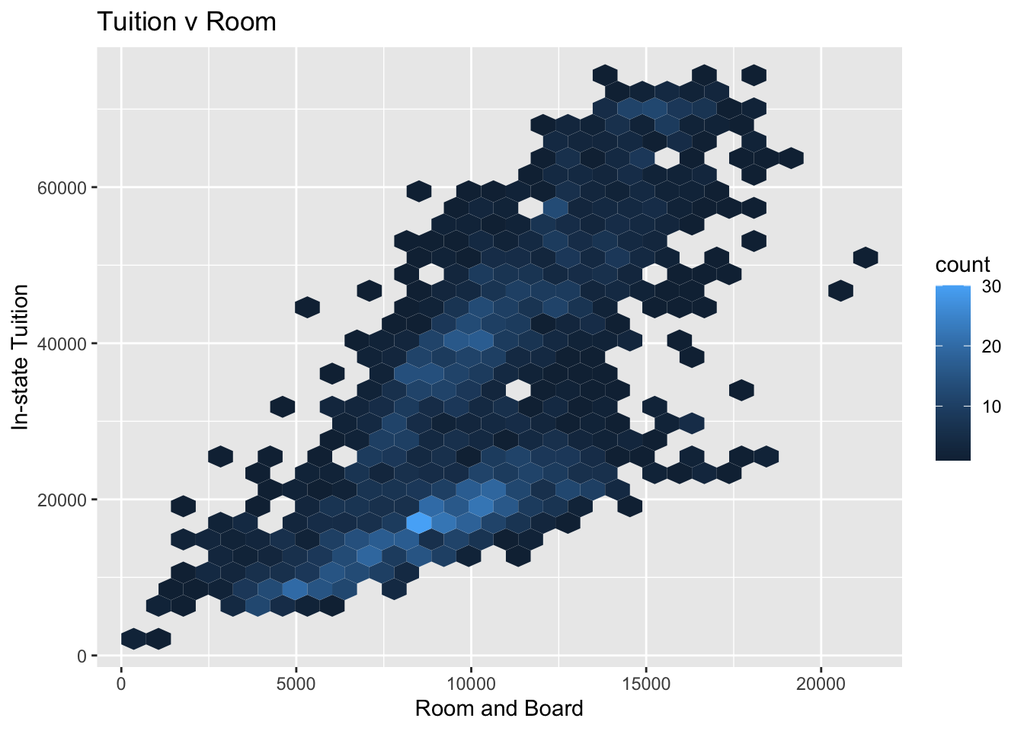

We choose this chart in expressing the information because this chart enables us to see clearly the relationship between tuition and rooms. Also, the color depth of each hexagon shows the number of colleges.

### Chart 3

This chart shows the relationship between in-state tuition and degree length in three different types of school.

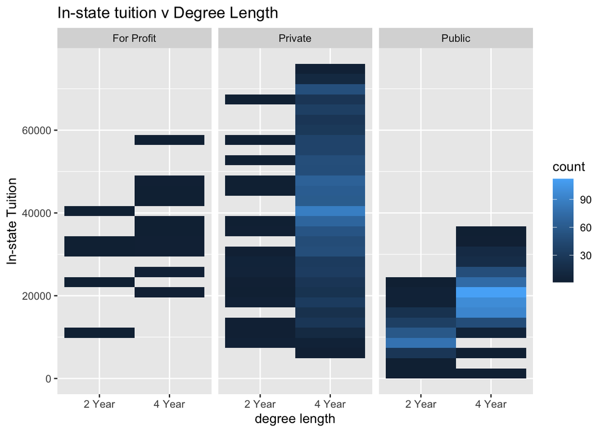

We choose this chart to express information because it divides the graph into three parts. Each part shows a different school type, and in each chart there’s a relationship we can observe through the position and color of each bar.